# 线性差分方程组解的性质

陈普

## 1.线性差分方程组的解的原理

具体见讲义，此处做一简单总结。

差分方程可以写成，

$$\Delta X_{t+1}=AX_t+b$$

或者展开成，
$$X_{t+1}=(A+I)X_t+b=\hat{A}X_t+b$$

很显然，稳态解为，
$$\bar{X}=-A^{-1}b$$

递归得到的解为，
$$X_t=\hat{A}^t(X_0-\bar{X})+\bar{X}$$

## 2. 代码和图形

### 2.1 全局稳定系统

$$\begin{bmatrix}X_{1,t+1}\\X_{2,t+1}\end{bmatrix}=\begin{bmatrix}1&0\\0&1\end{bmatrix}\begin{bmatrix}0.8&0\\0&0.7\end{bmatrix}\begin{bmatrix}1&0\\0&1\end{bmatrix}\begin{bmatrix}X_{1t}\\X_{2t}\end{bmatrix}+\begin{bmatrix}1\\ 2\end{bmatrix}$$

注意上式使用了$\hat{A}$的特征值分解形式。先来生成$A$矩阵和$b$向量，同时随便赋一个初值$X_0$，

```r
rm(list = ls())
library(matlab)
hatA <- matrix(c(1,0,0,1), nrow = 2) %*% diag(c(0.8,0.7)) %*% matrix(c(1,0,0,1), nrow = 2)
b <- matrix(c(1,2), ncol = 1)
X0 <- matrix(c(0,0), ncol = 1)
hatA
```

```
##      [,1] [,2]
## [1,]  0.8  0.0
## [2,]  0.0  0.7
```

```r
b
```

```
##      [,1]
## [1,]    1
## [2,]    2
```

```r
X0
```

```
##      [,1]
## [1,]    0
## [2,]    0
```

根据公式可以得到稳态解和递归的解，

```r
Xbar <- -solve(hatA - eye(2)) %*% b
Xbar # 稳态
```

```
##          [,1]
## [1,] 5.000000
## [2,] 6.666667
```

```r
Xt <- matrix(NA, nrow = 2, ncol = 30)
ans <- hatA
for (i in 1:ncol(Xt)) {
  Xt[,i] <- ans %*% (X0-Xbar)+Xbar
  ans <- ans %*% hatA
}
library(tidyverse)
Xt <- t(Xt) %>% as.data.frame()
Xt # 运动轨迹
```

```
##          V1       V2
## 1  1.000000 2.000000
## 2  1.800000 3.400000
## 3  2.440000 4.380000
## 4  2.952000 5.066000
## 5  3.361600 5.546200
## 6  3.689280 5.882340
## 7  3.951424 6.117638
## 8  4.161139 6.282347
## 9  4.328911 6.397643
## 10 4.463129 6.478350
## 11 4.570503 6.534845
## 12 4.656403 6.574391
## 13 4.725122 6.602074
## 14 4.780098 6.621452
```

[output cut: 16 more lines]

可以画个图看看。可以看到两个变量都收敛到各自的稳态。

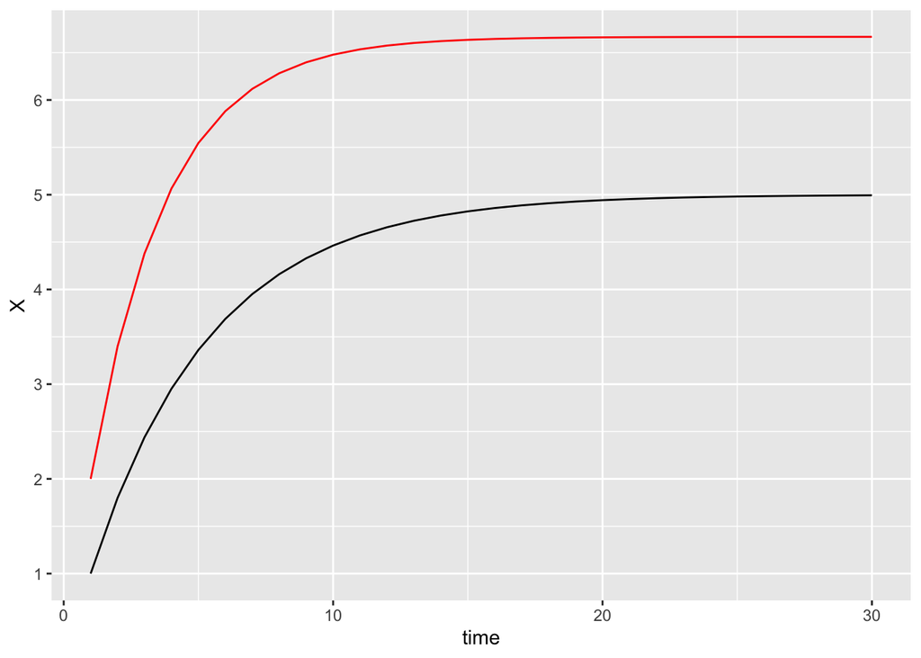

```r
Xt$tm <- 1:nrow(Xt)
ggplot(Xt, aes(x = tm, y = V1)) + geom_line() + geom_line(aes(y = V2), color = I('red')) + labs(x = 'time', y = 'X')
```

### 2.2 鞍点稳定系统

$$\begin{bmatrix}X_{1,t+1}\\X_{2,t+1}\end{bmatrix}=\begin{bmatrix}1&0\\0&1\end{bmatrix}\begin{bmatrix}1.8&0\\0&0.7\end{bmatrix}\begin{bmatrix}1&0\\0&1\end{bmatrix}\begin{bmatrix}X_{1t}\\X_{2t}\end{bmatrix}+\begin{bmatrix}1\\ 2\end{bmatrix}$$

更改矩阵$\hat{A}$的设置，使得系统是鞍点稳定，

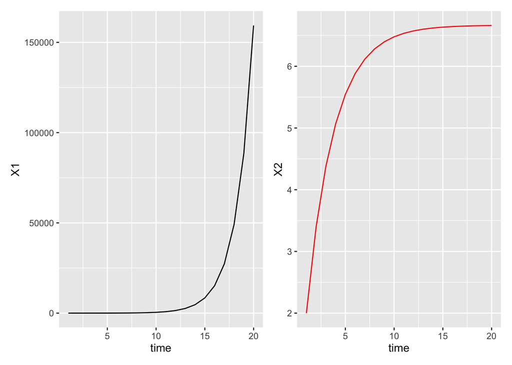

```r
hatA <- matrix(c(1,0,0,1), nrow = 2) %*% diag(c(1.8,0.7)) %*% matrix(c(1,0,0,1), nrow = 2)
Xbar <- -solve(hatA - eye(2)) %*% b
Xt <- matrix(NA, nrow = 2, ncol = 20)
ans <- hatA
for (i in 1:ncol(Xt)) {
  Xt[,i] <- ans %*% (X0-Xbar)+Xbar
  ans <- ans %*% hatA
}
Xt <- t(Xt) %>% as.data.frame()
Xt$tm <- 1:nrow(Xt)
p1 <- ggplot(Xt, aes(x = tm, y = V1)) + geom_line() + labs(x = 'time',y = 'X1')
p2 <- ggplot(Xt, aes(x = tm, y = V2)) + geom_line(color = I('red')) + labs(x = 'time',y = 'X2')
library(patchwork)
p1+ p2
```

双变量还有一种相位图非常有用。相位图只是上图的另外一种表述，相位图的横纵坐标为$X_1,X_2$，

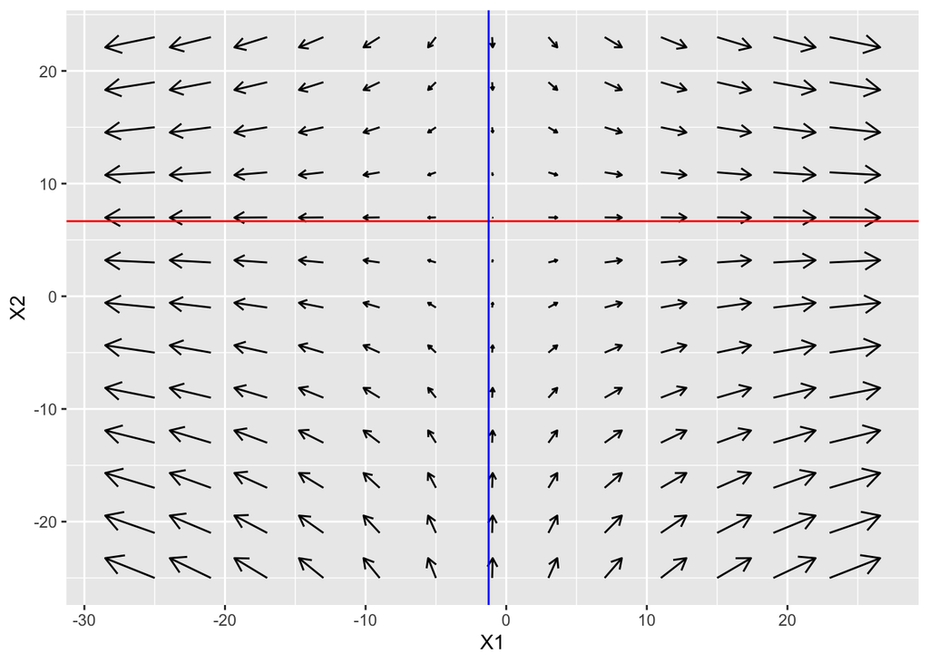

```r
library(ggquiver)
expand.grid(x = seq(-25,25,4), y = seq(-25,25,4)) %>%
  ggplot(aes(x,y,u=0.8*x+1,v = -0.3*y+2)) + geom_quiver() +
  geom_hline(yintercept = Xbar[2], color = I('red')) + labs(x = 'X1', y = 'X2') +
  geom_vline(xintercept = Xbar[1], color = I('blue'))
```

- 可以看到所有点趋向红线，但在x轴上发散。
- 但x轴的蓝线上是稳定的，这根线就是鞍点路径，只有在这条线上才能稳定，其他所有地方都是发散。

### 2.3 震荡发散和震荡稳定系统

$$\begin{bmatrix}X_{1,t+1}\\X_{2,t+1}\end{bmatrix}=\begin{bmatrix}1.5&1\\-1&0.6\end{bmatrix}\begin{bmatrix}X_{1t}\\X_{2t}\end{bmatrix}+\begin{bmatrix}1\\ 2\end{bmatrix}$$

我们这里构造一个特征值为复根的**震荡发散**的$\hat{A}$如下，

```r
hatA <- matrix(c(1.5,-1,1,0.6), nrow = 2)
eigen(hatA) # 特征值和特征向量
```

```
## eigen() decomposition
## $values
## [1] 1.05+0.893029i 1.05-0.893029i
##
## $vectors
##                       [,1]                  [,2]
## [1,]  0.7071068+0.0000000i  0.7071068+0.0000000i
## [2,] -0.3181981+0.6314665i -0.3181981-0.6314665i
```

```r
eigen(hatA) %>% .$values %>% Mod() # 特征值的模
```

```
## [1] 1.378405 1.378405
```

模大于1，可知必然发散。接下来计算系统随时间的运动轨迹，

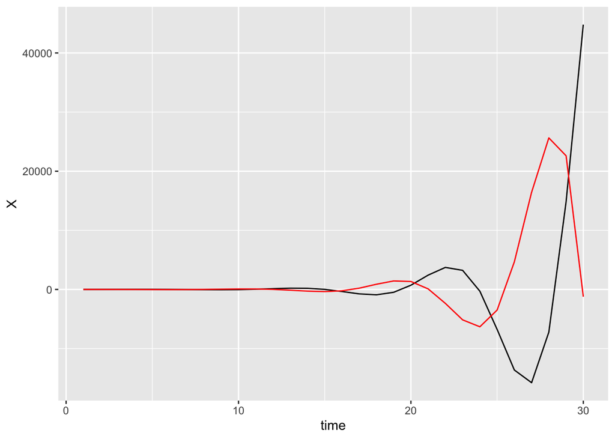

```r
Xbar <- -solve(hatA - eye(2)) %*% b
Xt <- matrix(NA, nrow = 2, ncol = 30)
ans <- hatA
for (n in 1:ncol(Xt)) {
  Xt[,n] <- ans %*% (X0-Xbar)+Xbar
  ans <- ans %*% hatA
}
Xt <- t(Xt) %>% as.data.frame()
Xt$tm <- 1:nrow(Xt)
ggplot(Xt, aes(x = tm, y = V1)) + geom_line() + geom_line(aes(y = V2), color = I('red')) + labs(x = 'time', y = 'X')
```

相位图如下，

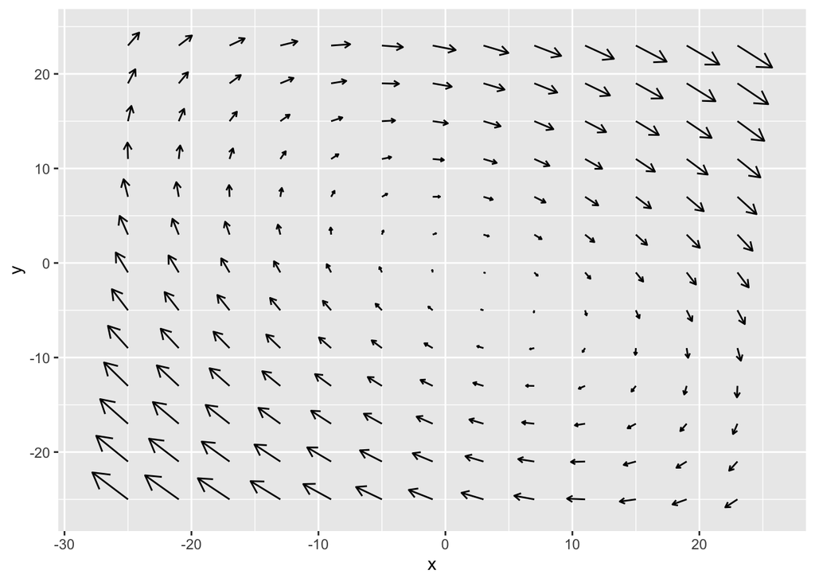

```r
expand.grid(x = seq(-25,25,4), y = seq(-25,25,4)) %>%
  ggplot(aes(x,y,u=0.5*x+y+1,v = -x-0.4*y+2)) + geom_quiver()
```

构造一个特征值为复根的**震荡稳定**的系统如下，
$$\begin{bmatrix}X_{1,t+1}\\X_{2,t+1}\end{bmatrix}=\begin{bmatrix}0&1\\-0.8&0.5\end{bmatrix}\begin{bmatrix}X_{1t}\\X_{2t}\end{bmatrix}+\begin{bmatrix}1\\ 2\end{bmatrix}$$

```r
hatA <- matrix(c(0,-0.8,1,0.5), nrow = 2)
eigen(hatA) # 特征值和特征向量
```

```
## eigen() decomposition
## $values
## [1] 0.25+0.8587782i 0.25-0.8587782i
##
## $vectors
##                     [,1]                [,2]
## [1,] 0.745356+0.0000000i 0.745356+0.0000000i
## [2,] 0.186339+0.6400955i 0.186339-0.6400955i
```

```r
eigen(hatA) %>% .$values %>% Mod() # 特征值的模
```

```
## [1] 0.8944272 0.8944272
```

绘制时间轨迹，

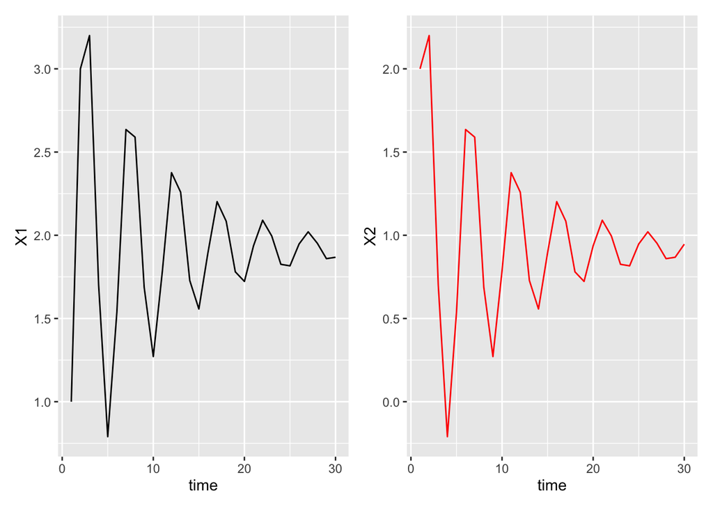

```r
Xbar <- -solve(hatA - eye(2)) %*% b
Xt <- matrix(NA, nrow = 2, ncol = 30)
ans <- hatA
for (n in 1:ncol(Xt)) {
  Xt[,n] <- ans %*% (X0-Xbar)+Xbar
  ans <- ans %*% hatA
}
Xt <- t(Xt) %>% as.data.frame()
Xt$tm <- 1:nrow(Xt)
p1 <- ggplot(Xt, aes(x = tm, y = V1)) + geom_line() + labs(x = 'time',y = 'X1')
p2 <- ggplot(Xt, aes(x = tm, y = V2)) + geom_line(color = I('red')) + labs(x = 'time',y = 'X2')
library(patchwork)
p1+ p2
```

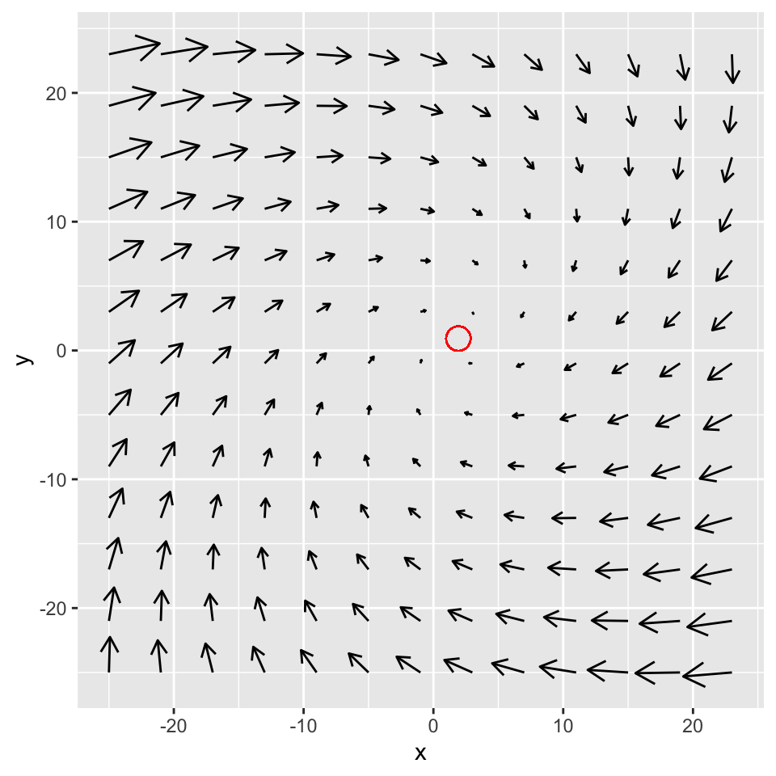

```r
expand.grid(x = seq(-25,25,4), y = seq(-25,25,4)) %>%
  ggplot(aes(x,y,u=-x+y+1,v = -0.8*x-0.5*y+2)) + geom_quiver() +
  geom_point(aes(x = Xbar[1], y = Xbar[2]), size = 5, color = I('red'), shape = 1)
```